# Part A. Processing and visualizing Twitter data

Load all packages here:

```r
suppressMessages(library("tidyverse"))
suppressMessages(library("maps"))
suppressMessages(library("stringr"))
suppressMessages(library("countrycode"))
```

1. The file `tweets.csv` contains around 100,000 geo-located tweets (each row is one tweet but the data does not contain the tweet texts) from 2020 and their automatically detected languages. Read the file into R and add country names derived from the geo-coordinates with the function `map.where()` from the `maps` package. Note that this function might return some outcomes like “country:region”. Therefore, in these cases delete everything from the “:” onwards with a regular expression to only keep the country name. Next, using this newly created country name column and the `countrycode` package, also add a column with ISO-2 country codes (iso2c). You might need to add some country codes manually where associated country names are not recognized by iso2c. In the end, your data frame/tibble should have the columns latitude, longitude, language, country, and country code. (6 points)

```r
# Loading twitter file
tweets <- read.csv("tweets.csv")

# Adding country and country_code information
tweets <- tweets %>%
          mutate(country = map.where("world", longitude, latitude),
                 country = str_replace(country, ":.*", ""),
                 country_code = countrycode(country, origin = "country.name",
                                            destination = "iso2c",
                                            custom_match = c("Kosovo" = "XK")))

# According to: https://laendercode.net/en/2-letter-code/xk
# The country code for Kosovo is "XK"
head(tweets)
```

```
##   latitude longitude language country country_code
## 1 48.38293 31.181446       uk Ukraine           UA
## 2 48.38293 31.181446       uk Ukraine           UA
## 3 48.38293 31.181446       ru Ukraine           UA
## 4 43.35315 -5.881200       es   Spain           ES
## 5 43.35315 -5.881200       es   Spain           ES
## 6 53.01940 -2.154013       en      UK           GB
```

2. Now examine the language data. How many unique languages did you find? Can you see which language code corresponds to tweets whose languages could not be predicted? **Delete the tweets/rows with undetermined language.** Which are the most popular languages? (4 points)

```r
# Examining language data
languages <- tweets %>%
             # Deleting rows with undetermined language
             filter(language != "und") %>%
             # Counting the number of tweets per language
             group_by(language) %>%
             summarise(n_tweets = n()) %>%
             ungroup() %>%
             # Sorting the data
             arrange(-n_tweets)

print(paste("Number of unique languages:", length(languages$language)))
```

```
## [1] "Number of unique languages: 50"
```

```r
print("The most popular languages were:")
```

```
## [1] "The most popular languages were:"
```

```r
head(languages)
```

```
## # A tibble: 6 × 2
##   language n_tweets
##   <chr>       <int>
## 1 en          36685
## 2 es          11475
## 3 tr          10152
## 4 fr           7050
## 5 it           3941
## 6 de           3534
```

3. Produce a map which displays the tweets with their location and also the language distribution by country. Have a look at Pablo Barberá’s [Twitter profile](https://twitter.com/p_barbera) for a clue how this map could look like with color representing languages. (11 points)

Hint: The map code from the streaming API examples can be a starting point here.

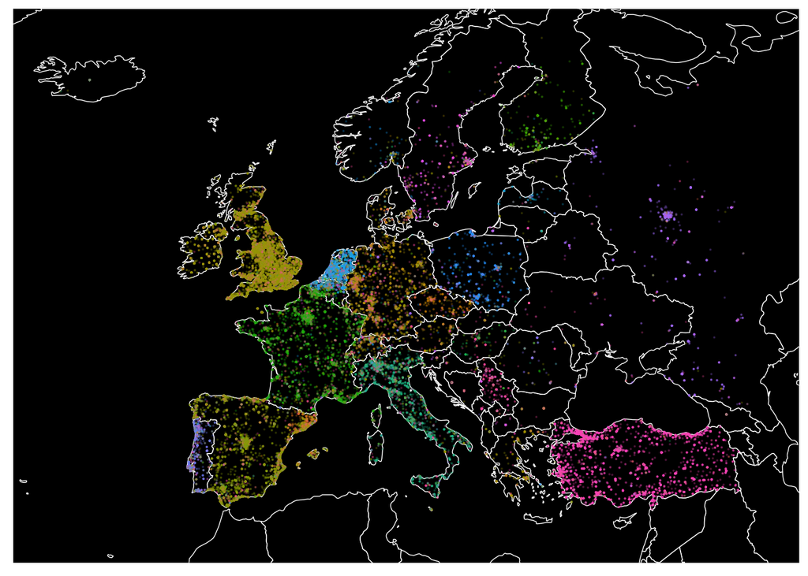

```r
# Creating a data frame with the map data
map.data <- map_data("world")

# Plotting the map with ggplot2:
tweets_map <- ggplot(map.data) +
              geom_map(aes(map_id = region), map = map.data, fill = "black",
                       color = "white", size = 0.25) +
              expand_limits(x = map.data$long, y = map.data$lat) +
              # Limits for x and y axis according to lat and lon
              scale_x_continuous(limits=c(-23, 47)) +
              scale_y_continuous(limits = c(34, 68)) +
              # Adding the dot for each tweet and specifying dot size, transparency, and colour
              geom_point(data = tweets,
                         aes(x = longitude, y = latitude, colour = language),
                         size = 0.05, alpha = 1/5) +
              # Removing unnecessary graph elements
              theme(axis.line = element_blank(),
                    axis.text = element_blank(),
                    axis.ticks = element_blank(),
                    axis.title = element_blank(),
                    legend.position = "none",
                    panel.background = element_rect(fill = "black"),
                    panel.border = element_blank(),
                    panel.grid.major = element_blank(),
                    panel.grid.minor = element_blank(),
                    plot.background = element_blank())
tweets_map
```

```r
# This map was adapted from the code provided in seminar week 8 available in:
# https://github.com/lse-my472/lse-my472.github.io/blob/master/week08/04-twitter-streaming-api.Rmd
```

4. Create a data frame with only four variables: `country`, `country_code`, `language`, and `n_tweets`, i.e. the number of tweets for each combination of country and language. To make it smaller, you can keep only the rows for which `n_tweets` is greater than 0! Save this data frame into a file called `part_a_country_language_distribution.csv` – we will work with it in Part B. Which countries produced the most and the least tweets? (2 points)

```r
# Creating a new data frame with the information requested
language_distribution <- tweets %>%
                         # Removing latitude and longitude
                         select(-longitude, -latitude) %>%
                         # Removing undetermined languages
                         filter(language != "und") %>%
                         # Counting tweets by country and language
                         group_by(country, country_code, language) %>%
                         summarise(n_tweets = n()) %>%
                         ungroup() %>%
                         arrange(-n_tweets)
# Saving the data frame as a csv file
write.csv(language_distribution, "part_a_country_language_distribution.csv")

print("The countries with more tweets were:")
```

```
## [1] "The countries with more tweets were:"
```

```r
head(language_distribution)
```

```
## # A tibble: 6 × 4
##   country country_code language n_tweets
##   <chr>   <chr>        <chr>       <int>
## 1 UK      GB           en          28986
## 2 Spain   ES           es          10350
## 3 Turkey  TR           tr           9542
## 4 France  FR           fr           6238
## 5 Italy   IT           it           3620
## 6 Germany DE           de           2865
```

```r
print("The countries with least tweets were:")
```

```
## [1] "The countries with least tweets were:"
```

```r
tail(language_distribution)
```

```
## # A tibble: 6 × 4
##   country country_code language n_tweets
##   <chr>   <chr>        <chr>       <int>
## 1 Ukraine UA           es              1
## 2 Ukraine UA           hi              1
## 3 Ukraine UA           ht              1
## 4 Ukraine UA           iw              1
## 5 Ukraine UA           lv              1
## 6 Ukraine UA           sv              1
```